# CS 396: Project Proposal

Multi-dimensional Analysis On New York City’s Airbnb Data

Jiwon Choi

# Proposed Problems

The era of post-COVID is coming, and many people started to plan their trip ahead. In order to provide a meaningful data to both suppliers (Airbnb hosts) and demanders (Airbnb users), this multi-dimensional analysis on Airbnb data is needed. What users may take a look at before make a final decision is not only the price and but also the reviews that other users have written before, and the description provided by the host. In case of hosts, they need to manually search what other hosts’ are doing in order to competitively compare themselves to one another. With these needs, some type of more intuitive, concise, and informative data visualization is needed, which can be easily understood and less time-consuming.

In order to tackle this purpose, further analysis on the followings are needed:

- Sentiment analysis per each county in New York City, to suggest users which area to consider.
- Word cloud plots so that users and hosts know the summarized keywords.
- Other additional visualizations that analyze the properties/amenities and price of the place.
- Based on the feature that the host has, give a reasonable price estimate on its price.

# Dataset

## About Dataset

In order to analyze the proposed problem, the dataset provided by Airbnb will be used. They provided the data here (http://insideairbnb.com/get-the-data.html), and they have a subsection for New York City which will be used in this study. Under New York City, there are multiple dataset that Airbnb has provided. Among 7 dataset that they have, this report plan to make a use of 4 of them: `listings_detail.csv`, `listings_summary.csv`, `reviews_details.csv`, and `reviews_summary.csv`. To briefly explain, the detail version contains more of raw and specific data, while summary data has summarized data only. Note that description of each field can be found here (https://docs.google.com/spreadsheets/d/1iWCNJcSutYqpULSQHlNyGInUvHg2BoUGoNRIGa6Szc4/edit#gid=982310896).

### 1. Listing Data

```python
import pandas as pd
data_path = "./data/"
df = pd.read_csv(data_path + "listings.csv")
pd.set_option('display.max_columns', None)
print("Data: listings_detail.csv")
```

```
## Data: listings_detail.csv
```

```python
df.info()
```

```
## <class 'pandas.core.frame.DataFrame'>
## RangeIndex: 36923 entries, 0 to 36922
## Data columns (total 74 columns):
##  #   Column                                        Non-Null Count  Dtype
## ---  ------                                        --------------  -----
##  0   id                                            36923 non-null  int64
##  1   listing_url                                   36923 non-null  object
##  2   scrape_id                                     36923 non-null  int64
##  3   last_scraped                                  36923 non-null  object
##  4   name                                          36910 non-null  object
##  5   description                                   35710 non-null  object
##  6   neighborhood_overview                         22510 non-null  object
##  7   picture_url                                   36923 non-null  object
##  8   host_id                                       36923 non-null  int64
##  9   host_url                                      36923 non-null  object
```

[output cut: 66 more lines]

```python
df = pd.read_csv(data_path + "listings_summary.csv")
print("Data: listings_summary.csv")
```

```
## Data: listings_summary.csv
```

```python
df.info()
```

```
## <class 'pandas.core.frame.DataFrame'>
## RangeIndex: 36923 entries, 0 to 36922
## Data columns (total 18 columns):
##  #   Column                          Non-Null Count  Dtype
## ---  ------                          --------------  -----
##  0   id                              36923 non-null  int64
##  1   name                            36910 non-null  object
##  2   host_id                         36923 non-null  int64
##  3   host_name                       36812 non-null  object
##  4   neighbourhood_group             36923 non-null  object
##  5   neighbourhood                   36923 non-null  object
##  6   latitude                        36923 non-null  float64
##  7   longitude                       36923 non-null  float64
##  8   room_type                       36923 non-null  object
##  9   price                           36923 non-null  int64
##  10  minimum_nights                  36923 non-null  int64
##  11  number_of_reviews               36923 non-null  int64
##  12  last_review                     27627 non-null  object
##  13  reviews_per_month               27627 non-null  float64
##  14  calculated_host_listings_count  36923 non-null  int64
##  15  availability_365                36923 non-null  int64
##  16  number_of_reviews_ltm           36923 non-null  int64
##  17  license                         0 non-null      float64
## dtypes: float64(4), int64(8), object(6)
## memory usage: 5.1+ MB
```

### 2. Review Data

```python
import pandas as pd
data_path = "./data/"
df = pd.read_csv(data_path + "reviews.csv")
pd.set_option('display.max_columns', None)
print("Data: reviews_detail.csv")
```

```
## Data: reviews_detail.csv
```

```python
df.info()
```

```
## <class 'pandas.core.frame.DataFrame'>
## RangeIndex: 848725 entries, 0 to 848724
## Data columns (total 6 columns):
##  #   Column         Non-Null Count   Dtype
## ---  ------         --------------   -----
##  0   listing_id     848725 non-null  int64
##  1   id             848725 non-null  int64
##  2   date           848725 non-null  object
##  3   reviewer_id    848725 non-null  int64
##  4   reviewer_name  848719 non-null  object
##  5   comments       847901 non-null  object
## dtypes: int64(3), object(3)
## memory usage: 38.9+ MB
```

```python
df = pd.read_csv(data_path + "reviews_summary.csv")
print("Data: reviews_summary.csv")
```

```
## Data: reviews_summary.csv
```

```python
df.info()
```

```
## <class 'pandas.core.frame.DataFrame'>
## RangeIndex: 848725 entries, 0 to 848724
## Data columns (total 2 columns):
##  #   Column      Non-Null Count   Dtype
## ---  ------      --------------   -----
##  0   listing_id  848725 non-null  int64
##  1   date        848725 non-null  object
## dtypes: int64(1), object(1)
## memory usage: 13.0+ MB
```

As seen in the `info()`, studying the full dataset will be a viable option. The `Non-Null Count` field has a minimum of 20,000+ for fields that are necessary to study. Even considering data cleaning, it will not go less than 20,000 samples since the fields with `NaN` fields are mostly a text data, which has a less probability of duplicate -i.e. host description field.

## Data Cleaning, Management, and EDA

### 1. Data Cleaning & Management

- Provided county description is already cleaned version in the column `neighbourhood_cleansed`. There is no duplicate values, or different format with a same meaning. Same for the `room_type` field.
- In `bathrooms_text` field, there are 2 samples which indicate that they have 10 and 10.5 baths. This seems to be an outlier and unrealistic, so manual check was done. It turned out that they rent out entire townhouse and apartment which sounds about to be right. They also indicated a similar number of bedrooms.
- The `price` entry has 36,923 data in total, but 36 samples have a price of $0.0. This seems to be faulty, so dropped them.
- The field of reviews: `review_scores_rating`, `review_scores_accuracy`, `review_scores_cleanliness`, `review_scores_checkin`, `review_scores_communication`, `review_scores_location`, and `review_scores_value` got some blank field, so dropped them. They remain to be over 25,000+ samples even excluding them.
- In the `description` field in `listings.csv` and the `comments` field in `reviews.csv`, if input includes newline it shows `<br>`, so we need to replace this into `""`.
- In `reviews.csv`, `comments` field where it has reviews are not in English. In this study, the text analysis is limited to English, and below is the refining process. This gives a result of 769,559, which is an accpetable amount of sample data.

```python
from polyglot.detect import Detector
import pandas as pd
data_path = "./data/"
df = pd.read_csv(data_path + "reviews.csv")
comments = df["comments"]
eng_count = 0
for c in comments:
  if type(c) is float: continue
  if ("<br>" in c): c.replace("<br>", "")
  try:
    c.encode('utf-8')
    lang = Detector(c, quiet=True)
    if (lang.language.name == "English"): eng_count += 1
  except: continue
print (eng_count)
```

[output not shown]

### 2. EDA

#### A. Non-Graphical EDA

```python
import pandas as pd
data_path = "./data/"
df = pd.read_csv(data_path + "listings.csv")
desc = df["review_scores_rating"].describe()
desc
```

```
## count    27627.000000
## mean         4.578315
## std          0.854467
## min          0.000000
## 25%          4.570000
## 50%          4.820000
## 75%          5.000000
## max          5.000000
## Name: review_scores_rating, dtype: float64
```

\

#### B. Graphical EDA

```python
import pandas as pd
import matplotlib.pyplot as plt
data_path = "./data/"
df = pd.read_csv(data_path + "listings.csv")
plt.hist(df["review_scores_rating"])
```

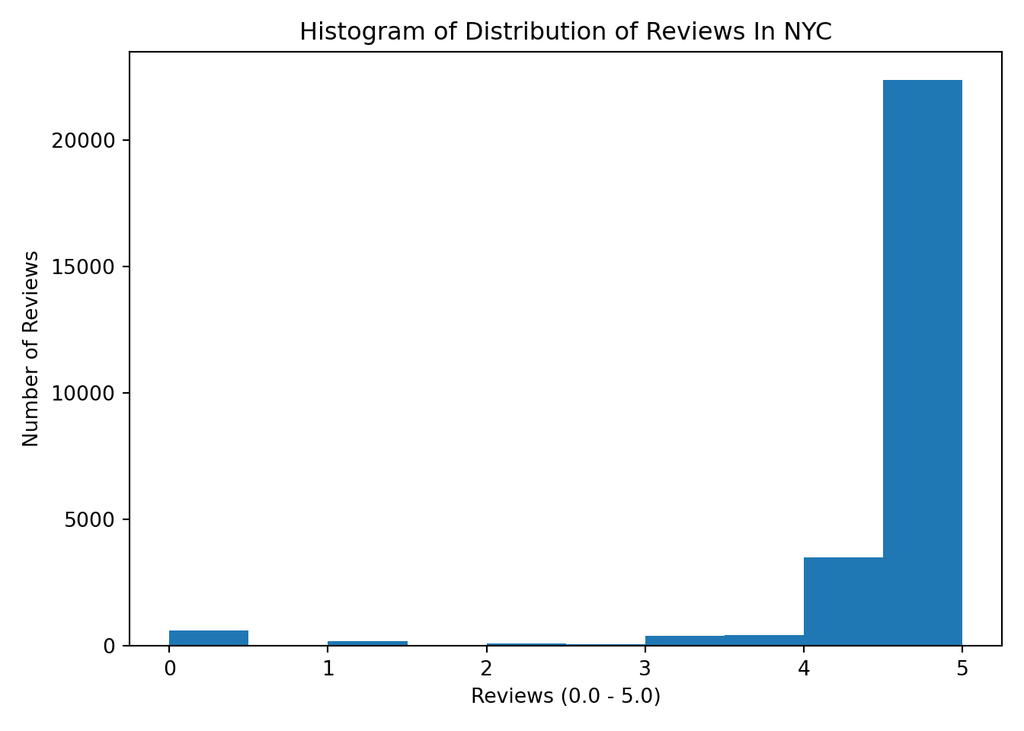

```python
plt.title("Histogram of Distribution of Reviews In NYC")
plt.xlabel("Reviews (0.0 - 5.0)")
plt.ylabel("Number of Reviews")
plt.tight_layout()
plt.show()
```

```python
import pandas as pd
import matplotlib.pyplot as plt
data_path = "./data/"
df = pd.read_csv(data_path + "listings.csv")
county = df["neighbourhood_group_cleansed"].unique()
avg_review = []
for c in county:
  avg = ((df[df["neighbourhood_group_cleansed"] == c])["number_of_reviews"]).mean()
  avg_review.append(avg)
plt.bar(county, avg_review)
```

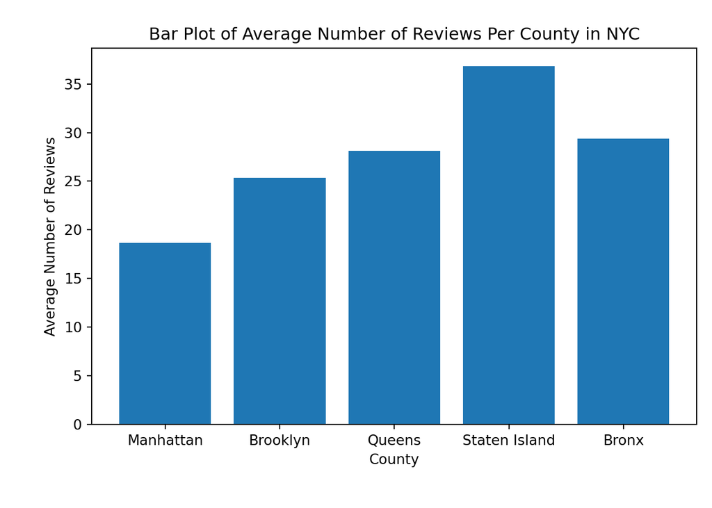

```python
plt.title("Bar Plot of Average Number of Reviews Per County in NYC")
plt.xlabel("County")
plt.ylabel("Average Number of Reviews")
plt.tight_layout()
plt.show()
```

```python
import pandas as pd
import matplotlib.pyplot as plt
data_path = "./data/"
df = pd.read_csv(data_path + "listings.csv")
county = df["price"]
county[:3]
```

```
## 0    $150.00
## 1     $76.00
## 2     $60.00
## Name: price, dtype: object
```

# Anticipated Method & Outcome